# Motion type prediction

Alexander Chumak

Sunday, September 27, 2015

## Introduction

The aim of the project is to pick up a model which would highly accurate predict the manner people did an exercise (biceps curl). Variable `classe` consits of 5 ways an exercise was done (both correctly and incorrectly).

## Loading the data

```r
training_raw <- read.csv("https://d396qusza40orc.cloudfront.net/predmachlearn/pml-training.csv")
```

Now, let us set seed for reproducibility.

```r
set.seed(18)
```

After that split our `training_raw` data set into actually training and validation so that we could estimate out-of-sample error.

```r
library(caret)
library(dplyr)
inTrain <- createDataPartition(y = training_raw$classe, p = .7, list = FALSE)
training <- training_raw[inTrain, ]
validation <- training_raw[-inTrain, ]
```

## Preprocessing

A good thing to do is to get rid of those variables, which variability is almost 0, i.e. they mostly have the same value occuring all the time. Such variables will not yield important information to us.

```r
nsv <- nearZeroVar(training, saveMetrics = TRUE)
training_nsv <- select(training, which(nsv$nzv == FALSE))
```

Also let us delete **exactly** the same variables from the validation set. It will make our calculations more simple in the future. Note: this action **will not** impose a bias on a validation set.

```r
validation_nsv <- select(validation, which(nsv$nzv == FALSE))
```

There are variables which mostly consist of NA values. These will cause our prediction models perform poorly. Let us get rid of them as well. It would cumbersome to give an evidence (the output of `nas` variable is pretty large), so you have to take it as a fact. All variables that we need have 0 amount of NAs.

```r
nas <- apply(validation_nsv, 2, function(x){
        sum(is.na(x))
})
validation_nsv <- select(validation_nsv, which(nas == 0))
training_nsv <- select(training_nsv, which(nas == 0))
```

### Dummy variables

There are also a couple of factor variables in our data sets, so we want them to transform into dummy ones.

```r
dummies <- dummyVars(classe ~ ., data = training_nsv)
training_nsv_dum <- as.data.frame(predict(dummies, newdata = training_nsv))
training_nsv_dum$classe <- training_nsv$classe
dummies2 <- dummyVars(classe ~ ., data = validation_nsv)
validation_nsv_dum <- as.data.frame(predict(dummies2, newdata = validation_nsv))
validation_nsv_dum$classe <- validation_nsv$classe
```

### Factor correlations

We might also suppose that some predictors are correlated with each other.

```r
M <- abs(cor(training_nsv_dum[, -83]))
diag(M) <- 0
which(M > .8, arr.ind = T)
```

```
##                   row col
## pitch_belt         32   2
## yaw_belt           33   2
## accel_belt_x       38   2
## magnet_belt_x      41   2
## magnet_dumbbell_z  69   5
## gyros_belt_x       35   7
## magnet_dumbbell_x  67   7
## magnet_dumbbell_y  68   7
## yaw_belt           33  31
## total_accel_belt   34  31
## accel_belt_y       39  31
## accel_belt_z       40  31
## user_name.adelmo    2  32
## accel_belt_x       38  32
## magnet_belt_x      41  32
## user_name.adelmo    2  33
## roll_belt          31  33
## roll_belt          31  34
## accel_belt_y       39  34
## accel_belt_z       40  34
## user_name.pedro     7  35
## user_name.adelmo    2  38
## pitch_belt         32  38
## magnet_belt_x      41  38
## roll_belt          31  39
## total_accel_belt   34  39
## accel_belt_z       40  39
## roll_belt          31  40
## total_accel_belt   34  40
## accel_belt_y       39  40
## user_name.adelmo    2  41
## pitch_belt         32  41
## accel_belt_x       38  41
## gyros_arm_y        49  48
## gyros_arm_x        48  49
## magnet_arm_x       54  51
## accel_arm_x        51  54
## magnet_arm_z       56  55
## magnet_arm_y       55  56
## accel_dumbbell_x   64  58
## accel_dumbbell_z   66  59
## pitch_dumbbell     58  64
## yaw_dumbbell       59  66
## user_name.pedro     7  67
## user_name.pedro     7  68
## user_name.eurico    5  69
```

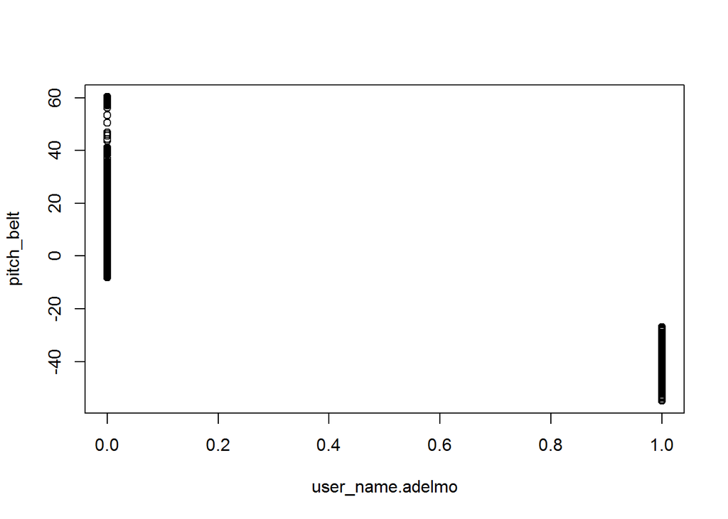

```r
plot(training_nsv_dum[, 2], training_nsv_dum[, 32], xlab = names(training_nsv_dum)[2], ylab = names(training_nsv_dum)[32])
```

As we may see from the plot Adelmo (one of 6 participants performing an exercise) has lower pitch belt than others.

## Model selection

Now, let us move to the most interesting part. First, define control parameters for our training function. We are going to use 10-fold cross-validation.

```r
fitControl <- trainControl(method = "cv", number = 10)
```

### Random forest

No preprocessing

```r
model_rf_no <- train(classe ~ ., data = training_nsv_dum, method = "rf",
                     trControl = fitControl)
```

Preprocessing with principal components.

```r
model_rf_pca <- train(classe ~ ., data = training_nsv_dum, method = "rf",
                     trControl = fitControl, preProcess = "pca")
model_rf_pca
```

```
## Random Forest
##
## 13737 samples
##    82 predictor
##     5 classes: 'A', 'B', 'C', 'D', 'E'
##
## Pre-processing: principal component signal extraction, scaled, centered
## Resampling: Cross-Validated (10 fold)
## Summary of sample sizes: 12363, 12365, 12363, 12363, 12364, 12365, ...
## Resampling results across tuning parameters:
##
##   mtry  Accuracy   Kappa      Accuracy SD  Kappa SD
##    2    0.9860966  0.9824142  0.003766114  0.004763169
##   42    0.9767076  0.9705348  0.004946767  0.006254301
##   82    0.9756891  0.9692468  0.005177393  0.006544998
##
## Accuracy was used to select the optimal model using  the largest value.
## The final value used for the model was mtry = 2.
```

Other models has been tested in a similar way but with different parameters. Here is a short summary:

- Random forest, no preprocessing – 0.9999
- Random forest, PCA preprocessing – 0.9864
- Decision tree, PCA preprocessing – 0.274
- Decision tree, no preprocessing – 0.7648
- Boosting, no preprocessing – 0.9967
- Boosting, PCA preprocessing – 0.7437

## Validation

I have decided to pick random forest model with PCA preprocessing. It shows good accuracy and principal components seem to be reasonable when it comes to such a great amount of variables. Here is testing results on a validation data set:

```r
predicted_rf_pca <- predict(model_rf_pca, newdata = validation_nsv_dum)
confusionMatrix(predicted_rf_pca, validation_nsv_dum$classe)
```

```
## Confusion Matrix and Statistics
##
##           Reference
## Prediction    A    B    C    D    E
##          A 1671    4    0    0    0
##          B    1 1128   14    0    0
##          C    1    7 1008   20    0
##          D    0    0    4  942    8
##          E    1    0    0    2 1074
##
## Overall Statistics
##
##                Accuracy : 0.9895
##                  95% CI : (0.9865, 0.9919)
##     No Information Rate : 0.2845
##     P-Value [Acc > NIR] : < 2.2e-16
##
##                   Kappa : 0.9867
##  Mcnemar's Test P-Value : NA
##
## Statistics by Class:
##
##                      Class: A Class: B Class: C Class: D Class: E
## Sensitivity            0.9982   0.9903   0.9825   0.9772   0.9926
## Specificity            0.9991   0.9968   0.9942   0.9976   0.9994
## Pos Pred Value         0.9976   0.9869   0.9730   0.9874   0.9972
## Neg Pred Value         0.9993   0.9977   0.9963   0.9955   0.9983
## Prevalence             0.2845   0.1935   0.1743   0.1638   0.1839
## Detection Rate         0.2839   0.1917   0.1713   0.1601   0.1825
## Detection Prevalence   0.2846   0.1942   0.1760   0.1621   0.1830
## Balanced Accuracy      0.9986   0.9936   0.9883   0.9874   0.9960
```

0.0081-0.0135 is a 95% CI for out-of-sample error.

## Visualisation

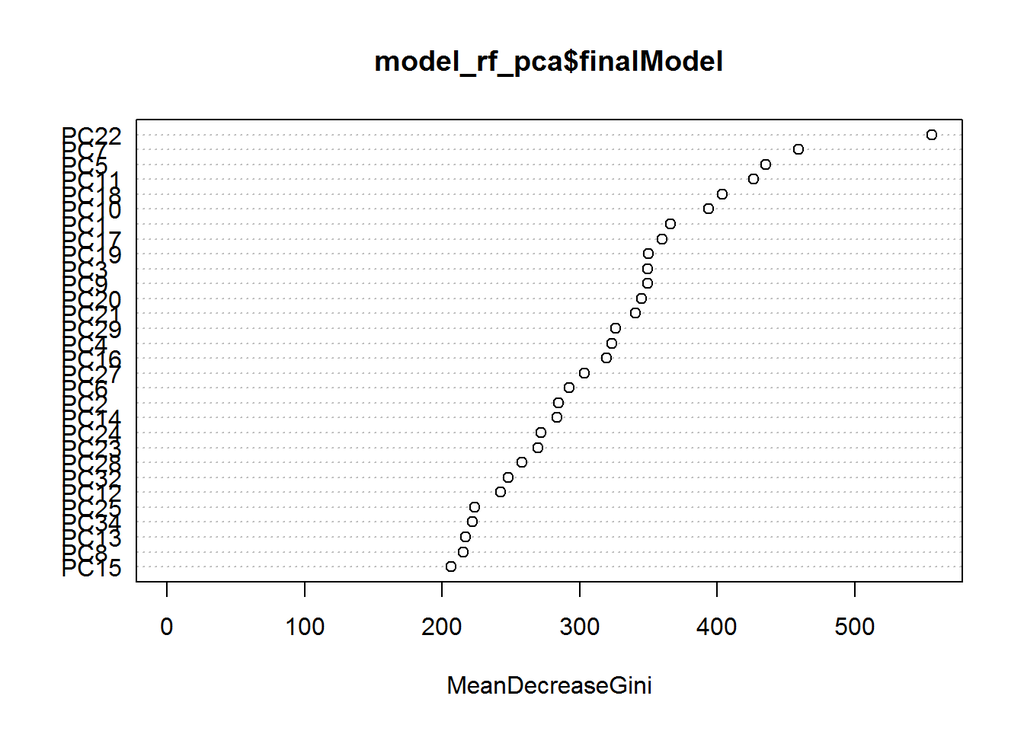

```r
library(randomForest)
varImpPlot(model_rf_pca$finalModel)
```

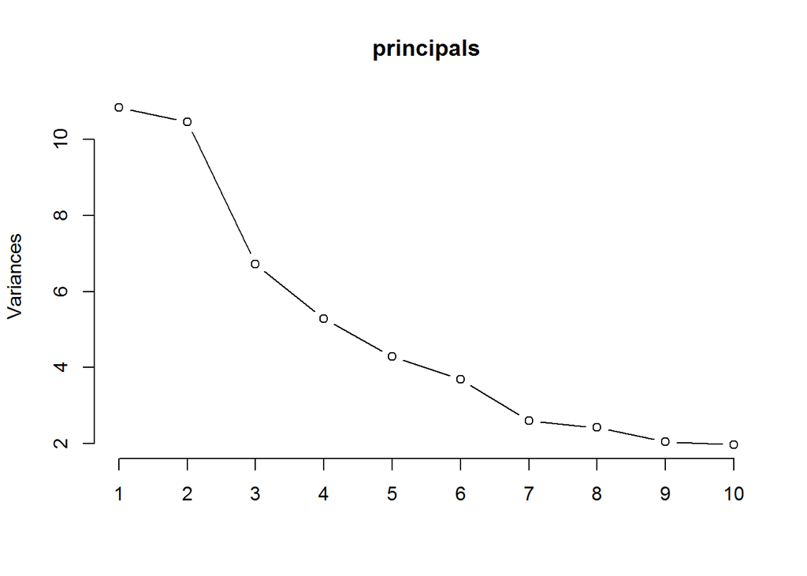

```r
principals <- prcomp(training_nsv_dum[, -83], center = TRUE, scale = TRUE)
plot(principals, type = "l")
```